# Solving the SIR model

Emma Davis

2026-02-20

### The SIR model

The SIR model separates a population into compartments:

- $S$: Susceptible
- $I$: Infectious
- $R$: Recovered/Removed

Then we can use initial (starting) values of $S$, $I$ and $R$ and rate of change equations to find out the expected values of $S$, $I$ and $R$ at any point in time.

#### Rate of change equations for the SIR model

As seen in lectures, the rate of change equations for the SIR model (using proportions rather than number of people) are:

#### Step 1: Define your parameters

```r
parameters <- c(beta = 0.3, gamma = 0.3, mu = 1/(70*365))
```

#### Step 2: Define your initial values

Next we want to define what the values of $S$, $I$ and $R$ are at the start of our time frame. Because they are proportions, they must take values between 0 and 1.

If we assume we are at the very start of a potential outbreak, then there will be no immune individuals, i.e. $R=0$. We will also have $S$ almost $=1$ and $I$ almost $=0$, with exact values depending on our population size. If we imagine a population of 10,000 people and only one infectious person, then we would have $I=0.0001$ and $S=1-I=0.9999$.

```r
initial_values <- c(S = 0.9999,
                    I = 0.0001,
                    R = 0)
initial_values
```

```
##      S      I      R
## 0.9999 0.0001 0.0000
```

#### Step 3: Write your model as a function

Now we want to take our rate of change equations and write them as a function. The function will need to use time, the current state of the values of $S$, $I$ and $R$, and the parameters, so we will include these as arguments.

Getting the right formatting inside the function definition is important to make sure your function matches with what the `deSolve` package expects.

- The order of your rate of change equations needs to be the same as when you defined your initial values.
- The use of `with(as.list(c(state, parameters)),...)` is also important as it:
  - Converts the vectors into type `list` using `as.list()`, which is the format `deSolve` expects.
  - Makes the names of the variables and parameters (e.g. `S` or `beta`) available using `with()`. It’s not vital to understand these parts of the setup, but it is important to include them in your function, including closing the brackets at the end of the function.

```r
SIRmodel <- function(t, state, parameters){
  with(as.list(c(state, parameters)),{

    # Rate of change equations
    dS <- mu - beta*S*I - mu*S
    dI <- beta*S*I - gamma*I - mu*I
    dR <- gamma*I - mu*R

    # Combine rates of change into a list
    list(c(dS, dI, dR))
  })
}
```

#### Step 4: Pick your time frame and intervals

Now we want to define how far long we want to run the model for and how frequently (at what intervals) we want to save the values of $S$, $I$ and $R$. If our parameters ($\beta$ and $\gamma$) are in terms of days, then the model output will be in units of days.

```r
times <- seq(0, 100, by = 1)
```

#### Step 5: Run the model

Now we have all the components we need, we can run the model using the `ode()` function from `deSolve`. The inputs for this function are:

- `y` - the vector of initial values for our $S$, $I$ and $R$ states
- `times` - the vector of times to output values for
- `func` - the model function
- `parms` - the vector of parameter values

We must make sure we use these names in our `ode()` function when assigning our inputs.

```r
out <- ode(y = initial_values,
           times = times,
           func = SIRmodel,
           parms = parameters)
head(out)
```

```
##      time         S            I            R
## [1,]    0 0.9999000 1.000000e-04 0.000000e+00
## [2,]    1 0.9998700 9.999219e-05 2.999648e-05
## [3,]    2 0.9998400 9.998348e-05 5.998918e-05
## [4,]    3 0.9998100 9.997431e-05 8.997991e-05
## [5,]    4 0.9997801 9.996426e-05 1.199666e-04
## [6,]    5 0.9997501 9.995330e-05 1.499489e-04
```

#### Step 6: Reformatting and plotting

Now we have run our model, we want to return to using `tidyverse` for manipulating and plotting the output by turning it into a tibble. The `data.frame()` step isn’t strictly necessary, but first converts `out` to being a standard data frame (rather than a deSolve object) before converting to a tibble. If we just used `as_tibble()` alone then everything would still work, we would just get some unnecessary warnings when using `ggplot` later.

```r
out <- as_tibble(data.frame(out))
out
```

```
## # A tibble: 101 × 4
##     time     S         I         R
##    <dbl> <dbl>     <dbl>     <dbl>
##  1     0 1.000 0.0001    0
##  2     1 1.000 0.0001000 0.0000300
##  3     2 1.000 0.0001000 0.0000600
##  4     3 1.000 0.0001000 0.0000900
##  5     4 1.000 0.0001000 0.000120
##  6     5 1.000 0.0001000 0.000150
##  7     6 1.000 0.0000999 0.000180
##  8     7 1.000 0.0000999 0.000210
##  9     8 1.000 0.0000999 0.000240
## 10     9 1.000 0.0000999 0.000270
## # ℹ 91 more rows
```

We can look at a few summary statistics:

```r
out %>% summarise(maxI = max(I), minS = min(S), maxR = max(R))
```

```
## # A tibble: 1 × 3
##     maxI  minS    maxR
##    <dbl> <dbl>   <dbl>
## 1 0.0001 0.997 0.00294
```

```r
out %>% summarise(lastI = last(I), lastS = last(S), lastR = last(R))
```

```
## # A tibble: 1 × 3
##       lastI lastS   lastR
##       <dbl> <dbl>   <dbl>
## 1 0.0000950 0.997 0.00294
```

And we can also plot our outbreak using `ggplot()`. To use ggplot in the way it’s intended, we first want to reformat our data using `gather()`.

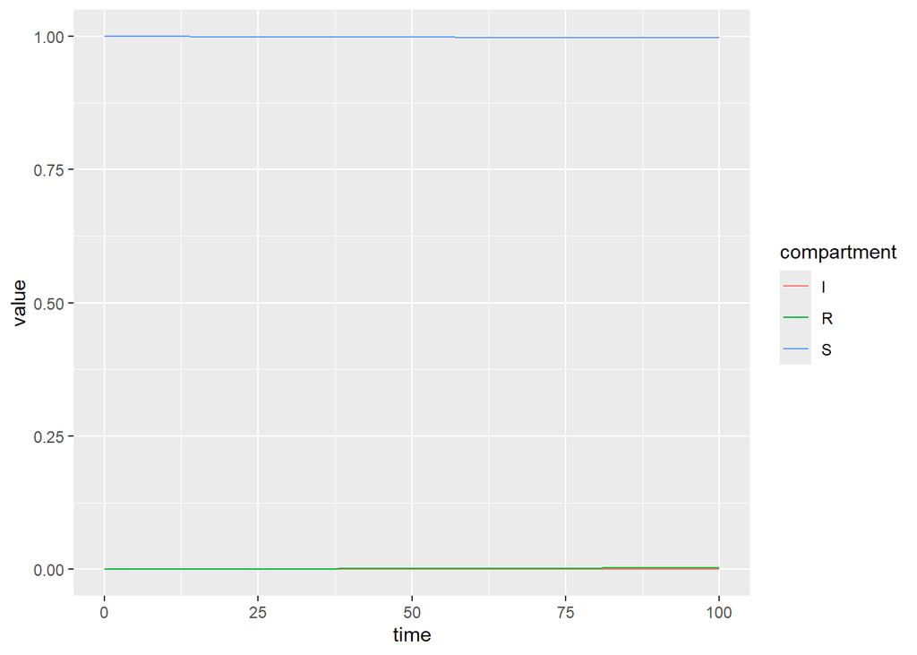

```r
df <- out %>% gather(key = compartment, value = value, c("S", "I", "R"))
df %>% ggplot(aes(x = time, y = value, group = compartment)) +
        geom_line(aes(color = compartment))
```

```r
df
```

```
## # A tibble: 303 × 3
##     time compartment value
##    <dbl> <chr>       <dbl>
##  1     0 S           1.000
##  2     1 S           1.000
##  3     2 S           1.000
##  4     3 S           1.000
##  5     4 S           1.000
##  6     5 S           1.000
##  7     6 S           1.000
##  8     7 S           1.000
##  9     8 S           1.000
## 10     9 S           1.000
## # ℹ 293 more rows
```

Then we can modify this plot using the methods we’ve covered and trialling things from our `ggplot` cheatsheet.

- We can use `fct_relevel()` inside `mutate()` to fix the order of $S$, $I$, and $R$ to a more natural order (`ggplot` defaults to alphabetical).
- We can also link the linetype to the compartment in the aesthetics of `geom_line()` and change the linewidth (this isn’t linked to compartment, so we can define it outside of `aes()`).
- We can pick colours manually using `scale_color_manual()` - similarly we could also do this with linetype using `scale_linetype_manual()` etc.
- We can use a theme, e.g. `theme_minimal()` to change the style of the plot and the font size.
- We can modify the axis and other labels using `labs()`.

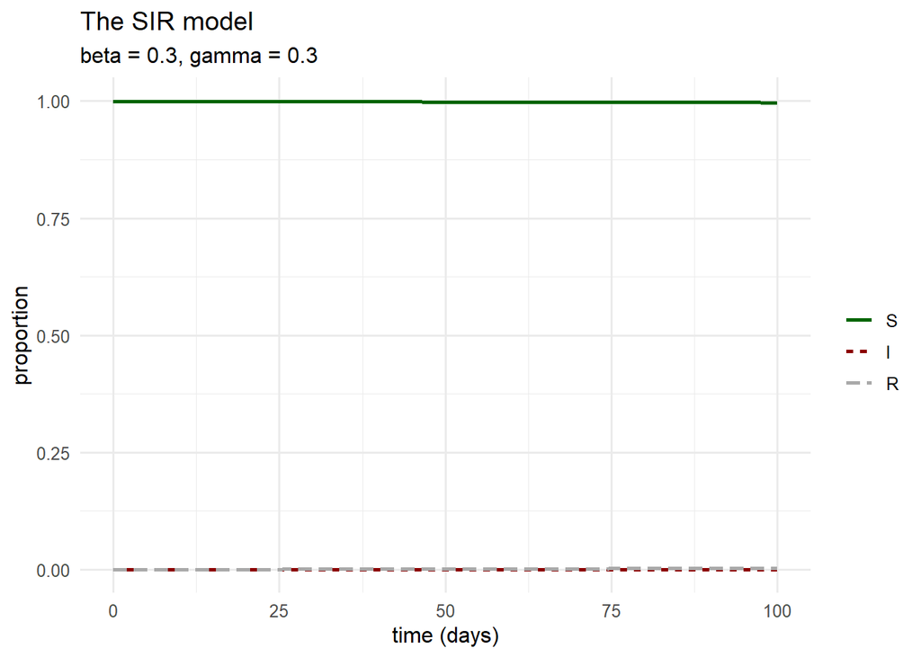

```r
df %>% mutate(compartment = fct_relevel(compartment,
                                        "S", "I", "R")) %>%
        ggplot(aes(x = time, y = value, group = compartment)) +
        geom_line(aes(color = compartment,
                      linetype = compartment),
                      linewidth = 1) +
        scale_color_manual(values = c("darkgreen",
                                      "darkred",
                                      "darkgrey")) +
        theme_minimal(base_size = 12) +
        labs(x = "time (days)",
             y = "proportion",
             title = "The SIR model",
             subtitle = "beta = 0.3, gamma = 0.3",
             color = "",
             linetype = "")
```